# Rstudio 에서 R markdown 화일로 HTML 리포트 작성하기

이용희

21/03/2019

## R markdown 화일 생성과 HTML 화일 만들기

### 준비

다음과 같이 5 가지 패키지를 사용할 수 있도록 `install.packages` 함수를 이용하여 설치해준다. **만약 이미 설치가 되어있다면 다시 설치할 필요가 없다.**

또한 `tidyr`과 `kableExtra` 라이브러리를 사용할 수 있도록 불러준다.

```r
#install.packages("rmarkdown")
#install.packages("knitr")
#install.packages("kableExtra")
#install.packages("tidyr")
#install.packages("prettydoc")
library(kableExtra)
library(tidyr)
```

### Rmarkdown 화일 생성

먼저 다음과 같이 Rstudio에서 새로운 R markdown 화일을 생성한다.

[figure not shown]

다음과 같은 창이 뜨는데 제목과 저자를 입력하고 OK를 누르면 R markdown 화일이 생성된다.

[figure not shown]

R markdown 화일은 다음과 같은 명령문(header)으로 시작하고 `title:`, `author:`, `date:` 다음에 나오는 정보는 바꿀 수 있다. 아래에 나온 명령문 다음부터는 자유롭게 R markdown 명령을 사용하여 바꿀 수 있다.

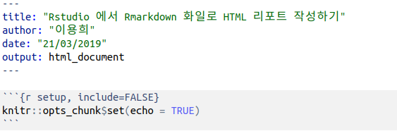

이제 바꾸어야할 정보를 바꾼 후에 `File -> Save as`로 화일 이름을 자신의 것으로 바꾸어 저장해 보자. 화일 이름의 확장자는 `.rmd`로 한다. 저장할 때 인코딩(encoding)에 대한 선택을 하라고 묻는데 `UTF-8`로 선택하여 저장한다.

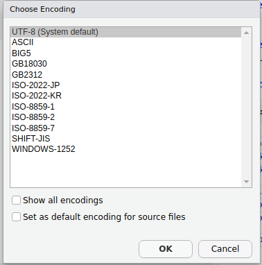

### R markdown 화일을 HTML 화일로 만들기

[figure not shown]

### `prettydoc` 라이브러리를 이용한 보기 좋은 HTML 화일 만들기

`prettydoc` 라이브러리를 설치하고 R markdown 화일의 앞부분(header)을 다음과 같이 바꾸어 주면 더욱 보기 좋은 HTML 화일을 만들 수 있다.

아래 header 에서 주의할 점은 **들여쓰기를 반드시 2칸 단위**로 해주어야 한다는 점이다.

```
---
title: "Rstudio 에서 Rmarkdown 화일로 HTML 리포트 작성하기"
author: "이용희"
date: "21/03/2019"
output:
  prettydoc::html_pretty:
    theme: cayman
    highlight: vignette
---
```

## R markdown 의 기초

R markdown은 간단한 명령을 통하여 제목, 진한 글자, 기울인 글자, 항목들, 그림 등을 다양한 모양으로 입력하고 조절하여 HTML 형식의 화일을 생성할 수 있다. 더 나아가 R 명령어들을 실행시켜서 그 결과를 HTML 화일에 볼 수 있게 한다.

다음은 R markdown 명령문들에 대한 설명이다.

### 본문과 글자

본문은 영문과 한글을 동시에 사용해도 상관없다. This is my fisrt Rmarkdown file.

문단과 문단은 한 줄을 띄어서 구별한다.

기울어진 글씨(italic)를 사용하는 경우 글자들을 `*`로 다음과 같이 선택해준다. 주의할 점은 `*`와 글자 사이에 공백이 있으면 안된다.

```
*기울어진 글씨*
```

*기울어진 글씨*

진한 글씨(bold)를 사용하는 경우 글자들을 `**`로 다음과 같이 선택해준다. 주의할 점은 `**`와 글자 사이에 공백이 있으면 안된다.

```
**진한 글씨**
```

**진한 글씨**

### 제목

`#`으로 시작하면 큰 제목(heading)이 되고 다음과 같이 제목의 크기를 `#`의 개수로 조정할 수 있다.

```
# 제목1

## 제목2

### 제목3

#### 제목4

##### 제목5

###### 제목6
```

# 제목1

## 제목2

### 제목3

#### 제목4

##### 제목5

###### 제목6

### 항목

순서가 없는 항목(unordered list)는 공백없이 `*`로 시작한다. `*` 다음에는 공백이 한 칸 있어야한다.

```
* 항목 1
* 항목 2
* 항목 3
```

- 항목 1
- 항목 2
- 항목 3

순서가 있는 항목(ordered list)는 공백없이 숫자와 점으로(즉 `1.`) 시작한다. `1.` 다음에는 공백이 한 칸 있어야한다.

```
1. 항목 1
2. 항목 2
3. 항목 3
```

1. 항목 1
2. 항목 2
3. 항목 3

항목들이 내포된(nested list) 경우 안쪽의 항목들이 바깥쪽 항목에서 **4 칸을 들여쓰면** 된다. 순서가 없는 항목의 모양은 `*`, `+`, `-`에 따라서 다르다.

```
* 항목 1
    1. 부항목 1
    2. 부항목 2
* 항목 2
    + 부항목 1
    + 부항목 2
        - 부부항목 1
        - 부부항목 2
    + 부항목 3
* 항목 3
```

- 항목 1
  1. 부항목 1
  2. 부항목 2
- 항목 2
  - 부항목 1
  - 부항목 2
    - 부부항목 1
    - 부부항목 2
  - 부항목 3
- 항목 3

### 그림화일 넣기

그림화일은 다음과 같이 불러올 수 있다. 예를 들어 그림화일이 `cat.jpeg`로 저장되어 있다면 다음과 같은 명령을 수행하면 그림을 그려주고 `[...]` 안의 내용을 캡션으로 보여준다.

주의할 점은 그림화일이 R markdown 화일과 같은 디렉토리에 있어야 한다.

```
![고양이 그림](cat.jpeg)
```

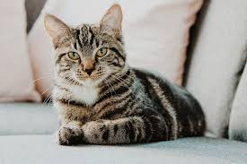

고양이 그림

### 링크 만들기

웹사이트에 대한 링크는 다음과 같이 만들 수 있다.

```
[서울시립대 홈페이지](http://www.uos.ac.kr)
```

[서울시립대 홈페이지](http://www.uos.ac.kr) 를 클릭하면 링크된 페이지로 이동한다.

또는 `<...>` 안에 웹사이트 주소를 넣으면 링크가 생성된다.

```
<http://www.uos.ac.kr>
```

http://www.uos.ac.kr 를 클릭하면 링크된 페이지로 이동한다.

### R 명령문의 실행

R 의 명령문(R code chunk)은 `` ```{r} `` 으로 시작해서 다음 칸 부터 명령문을 넣어주고 마지막에 `` ``` `` 으로 끝난다. 여기서 `` ` ``는 키보드 왼쪽 위에 있는 기호이며 code chunk는 기호를 세 번 반복한다(즉 `` ``` ``).

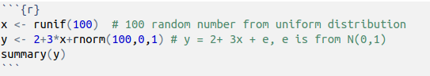

위와 같이 R 명령문을 쓰고 실행하면 다음과 같은 결과를 얻게된다.

```r
x <- runif(100)  # 100 random number from uniform distribution
y <- 2+3*x+rnorm(100,0,1) # y = 2+ 3x + e, e is from N(0,1)
summary(y)
```

```
##    Min. 1st Qu.  Median    Mean 3rd Qu.    Max.
## -0.1459  2.4940  3.5378  3.4543  4.3605  6.9811
```

그림도 다음과 같이 그릴 수 있다.

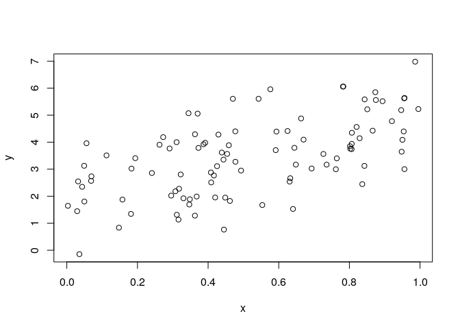

```r
plot(x,y)
```

그림을 크게 그리고 싶으면 `` ```{r dpi=200} ``과 같은 선택문(`dpi=XXX`)을 사용할 수 있다.

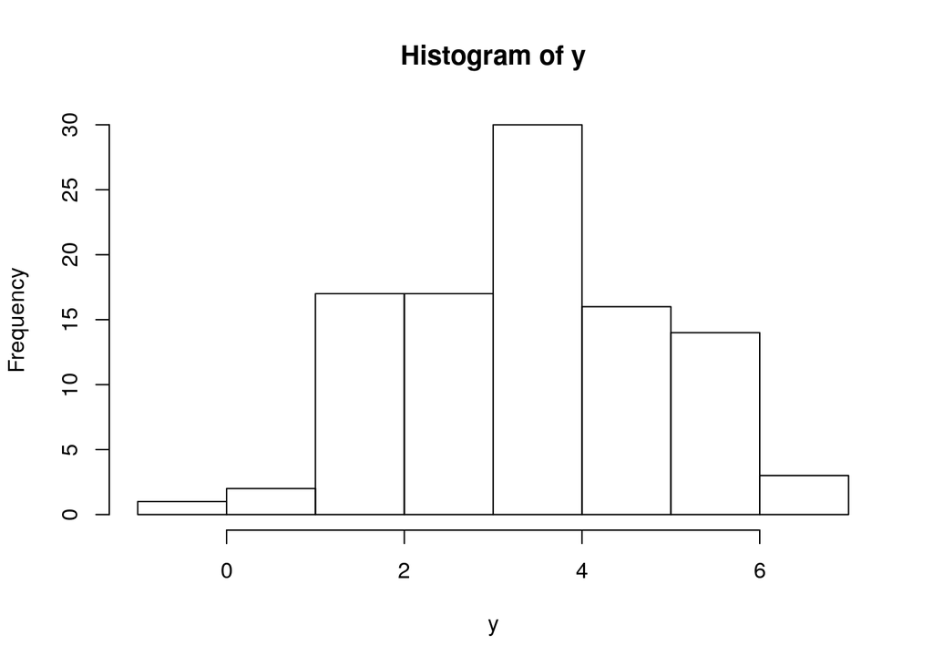

```r
hist(y)
```

### R 명령어 표기

본문에서 R 명령어를 고딕체로 표현하고 싶으면 기호 `` ` `` 를 명령어 앞과 뒤에 붙여주면 된다. 예를 들어 R 함수의 이름을 `summary(y)`와 같이 하이라이트된 고딕체로 표시할 수 있다.

### `kable` 함수로 Dataframe을 표로 출력하기

다음과 같이 data frame을 `kable` 함수로 표를 출력할 수 있다.

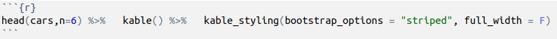

```r
head(cars,n=6) %>%   kable() %>%   kable_styling(bootstrap_options = "striped", full_width = F)
```

| speed | dist |
| --- | --- |
| 4 | 2 |
| 4 | 10 |
| 7 | 4 |
| 7 | 22 |
| 8 | 16 |
| 9 | 10 |